# Introduction to Matplotlib for absolute beginners

Matplotlib is an open source, free low level graph plotting library in python that serves as a visualization utility.

## Installing & importing

```python
%pip install matplotlib
```

Most of the Matplotlib utilities lies under the pyplot submodule, and are usually imported under the plt alias:

```python
import matplotlib.pyplot as plt
```

### draw lines

The plot() function is used to draw points (markers) in a diagram.

By default, the plot() function draws a line from point to point.

The function takes parameters for specifying points in the diagram.

- Parameter 1 is an array containing the points on the x-axis.
- Parameter 2 is an array containing the points on the y-axis.

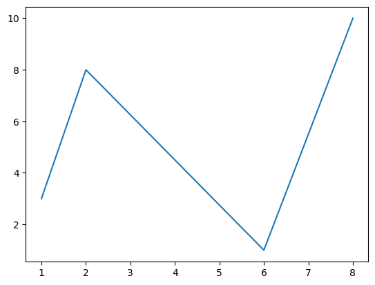

```python
import numpy as np
xpoints = np.array([1, 2, 6, 8])
ypoints = np.array([3, 8, 1, 10])

plt.plot(xpoints, ypoints)
plt.show()
```

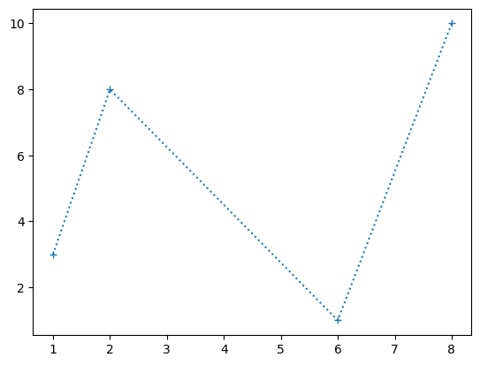

```python
plt.plot(xpoints, ypoints,'+',ls=':')
plt.show()
```

### Adding style!

Marker shape:

```
'o'	Circle
'*'	Star
'.'	Point
'+'	Plus
```

Line style:

```
'-'	Solid line
':'	Dotted line
'--'	Dashed line
'-.'	Dashed/dotted line
```

Color:

```
'r'	Red
'g'	Green
'b'	Blue
```

Marker size, using ms kw argument.

```
[ 3  8  1 10]
```

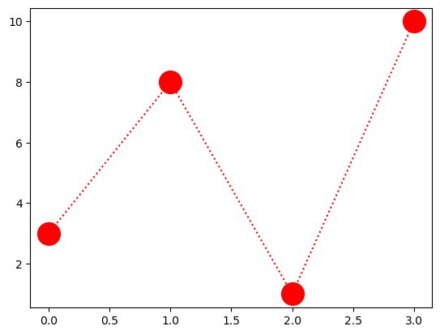

```python
print(ypoints)
plt.plot(ypoints, marker = 'o', ms = 20, color='red', linestyle=':')
```

### Draw Multiple Lines

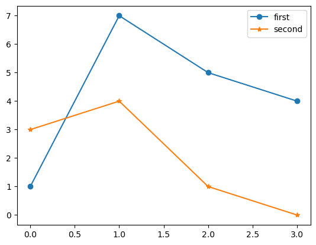

```python
y1 = np.array([1,7,5,4])
y2 = np.array([3,4,1,0])

plt.plot(y1, marker='o',label='first')
plt.plot(y2, marker ='*',label='second')
plt.legend()
plt.show()
```

### Set labels & title

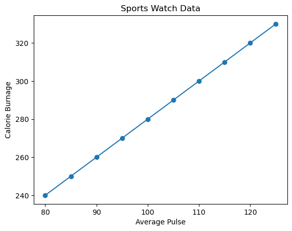

```python
x = np.array([80, 85, 90, 95, 100, 105, 110, 115, 120, 125])
y = np.array([240, 250, 260, 270, 280, 290, 300, 310, 320, 330])

plt.plot(x, y, marker='o')

plt.title("Sports Watch Data")
plt.xlabel("Average Pulse")
plt.ylabel("Calorie Burnage")

plt.show()
```

### Scatter plot

With Pyplot, you can use the scatter() function to draw a scatter plot.

The scatter() function plots one dot for each observation. It needs two arrays of the same length, one for the values of the x-axis, and one for values on the y-axis.

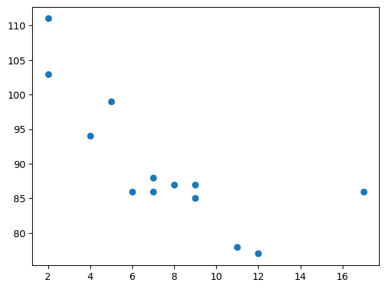

```python
import matplotlib.pyplot as plt
import numpy as np

x = np.array([5,7,8,7,2,17,2,9,4,11,12,9,6])
y = np.array([99,86,87,88,111,86,103,87,94,78,77,85,86])

plt.scatter(x, y)

plt.show()
```

### bar plot

The categories and their values represented by the first and second argument as arrays.

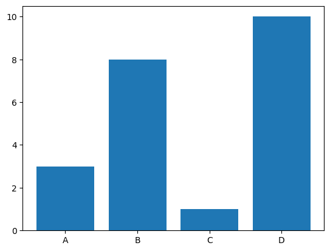

```python
x = np.array(["A", "B", "C", "D"])
y = np.array([3, 8, 1, 10])

plt.bar(x,y)
plt.show()
```

### Pie chart

The pie chart draws one piece (called a wedge) for each value in the array.

By default the plotting of the first wedge starts from the x-axis and moves counterclockwise:

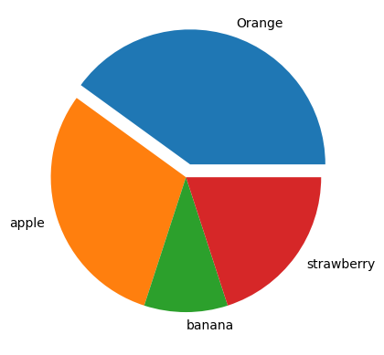

```python
y = np.array([4,3,1,2])

plt.pie(y, labels = ['Orange','apple','banana', 'strawberry'], explode=[0.1,0,0,0])
plt.show()
```

### Matplotlib Object Hierarchy

a plot is really a hierarchy of nested Python objects. A “hierarchy” here means that there is a tree-like structure of matplotlib objects underlying each plot.

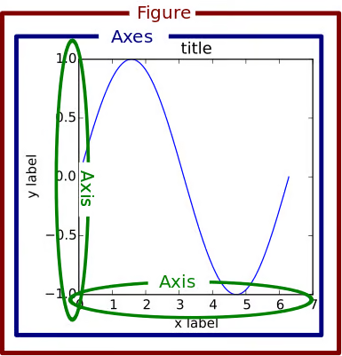